# Risk Factor Analysis

## Outcome Variable

**Outcome Variable:** whz

## Predictor Variables

**Intervention Variable:** hfoodsec

**Adjustment Set:**

- arm
- sex
- W_mage
- meducyrs
- feducyrs
- hhwealth_quart
- vagbrth
- W_nrooms
- W_nchldlt5
- brthmon
- W_parity
- impfloor
- impsan
- safeh20
- delta_W_mage
- delta_meducyrs
- delta_feducyrs
- delta_hhwealth_quart
- delta_vagbrth
- delta_W_nrooms
- delta_W_nchldlt5
- delta_brthmon
- delta_W_parity
- delta_impfloor
- delta_impsan
- delta_safeh20

## Stratifying Variables

The analysis was stratified on these variable(s):

- agecat
- studyid
- country

## Data Summary

| agecat | studyid | country | hfoodsec | n_cell | n |
| --- | --- | --- | --- | --- | --- |
| Birth | ki0047075b-MAL-ED | BANGLADESH | Food Secure | 151 | 178 |
| Birth | ki0047075b-MAL-ED | BANGLADESH | Mildly Food Insecure | 3 | 178 |
| Birth | ki0047075b-MAL-ED | BANGLADESH | Food Insecure | 24 | 178 |
| Birth | ki0047075b-MAL-ED | BRAZIL | Food Secure | 0 | 102 |
| Birth | ki0047075b-MAL-ED | BRAZIL | Mildly Food Insecure | 11 | 102 |
| Birth | ki0047075b-MAL-ED | BRAZIL | Food Insecure | 91 | 102 |
| Birth | ki0047075b-MAL-ED | INDIA | Food Secure | 151 | 167 |
| Birth | ki0047075b-MAL-ED | INDIA | Mildly Food Insecure | 2 | 167 |
| Birth | ki0047075b-MAL-ED | INDIA | Food Insecure | 14 | 167 |
| Birth | ki0047075b-MAL-ED | NEPAL | Food Secure | 75 | 96 |
| Birth | ki0047075b-MAL-ED | NEPAL | Mildly Food Insecure | 9 | 96 |
| Birth | ki0047075b-MAL-ED | NEPAL | Food Insecure | 12 | 96 |
| Birth | ki0047075b-MAL-ED | PERU | Food Secure | 26 | 105 |
| Birth | ki0047075b-MAL-ED | PERU | Mildly Food Insecure | 24 | 105 |
| Birth | ki0047075b-MAL-ED | PERU | Food Insecure | 55 | 105 |
| Birth | ki0047075b-MAL-ED | SOUTH AFRICA | Food Secure | 106 | 193 |
| Birth | ki0047075b-MAL-ED | SOUTH AFRICA | Mildly Food Insecure | 17 | 193 |
| Birth | ki0047075b-MAL-ED | SOUTH AFRICA | Food Insecure | 70 | 193 |
| Birth | ki1017093-NIH-Birth | BANGLADESH | Food Secure | 3 | 28 |
| Birth | ki1017093-NIH-Birth | BANGLADESH | Mildly Food Insecure | 21 | 28 |
| Birth | ki1017093-NIH-Birth | BANGLADESH | Food Insecure | 4 | 28 |
| Birth | ki1017093c-NIH-Crypto | BANGLADESH | Food Secure | 14 | 23 |
| Birth | ki1017093c-NIH-Crypto | BANGLADESH | Mildly Food Insecure | 6 | 23 |
| Birth | ki1017093c-NIH-Crypto | BANGLADESH | Food Insecure | 3 | 23 |
| Birth | kiGH5241-JiVitA-3 | BANGLADESH | Food Secure | 4974 | 10289 |
| Birth | kiGH5241-JiVitA-3 | BANGLADESH | Mildly Food Insecure | 3502 | 10289 |
| Birth | kiGH5241-JiVitA-3 | BANGLADESH | Food Insecure | 1813 | 10289 |
| Birth | kiGH5241-JiVitA-4 | BANGLADESH | Food Secure | 334 | 680 |
| Birth | kiGH5241-JiVitA-4 | BANGLADESH | Mildly Food Insecure | 250 | 680 |
| Birth | kiGH5241-JiVitA-4 | BANGLADESH | Food Insecure | 96 | 680 |

[output cut: 66 more lines]

The following strata were considered:

- agecat: 24 months, studyid: ki0047075b-MAL-ED, country: BANGLADESH
- agecat: 24 months, studyid: ki0047075b-MAL-ED, country: BRAZIL
- agecat: 24 months, studyid: ki0047075b-MAL-ED, country: INDIA
- agecat: 24 months, studyid: ki0047075b-MAL-ED, country: NEPAL
- agecat: 24 months, studyid: ki0047075b-MAL-ED, country: PERU
- agecat: 24 months, studyid: ki0047075b-MAL-ED, country: SOUTH AFRICA
- agecat: 24 months, studyid: ki1017093-NIH-Birth, country: BANGLADESH
- agecat: 24 months, studyid: ki1017093c-NIH-Crypto, country: BANGLADESH
- agecat: 24 months, studyid: ki1113344-GMS-Nepal, country: NEPAL
- agecat: 24 months, studyid: kiGH5241-JiVitA-3, country: BANGLADESH
- agecat: 24 months, studyid: kiGH5241-JiVitA-4, country: BANGLADESH
- agecat: 6 months, studyid: ki0047075b-MAL-ED, country: BANGLADESH
- agecat: 6 months, studyid: ki0047075b-MAL-ED, country: BRAZIL
- agecat: 6 months, studyid: ki0047075b-MAL-ED, country: INDIA
- agecat: 6 months, studyid: ki0047075b-MAL-ED, country: NEPAL
- agecat: 6 months, studyid: ki0047075b-MAL-ED, country: PERU
- agecat: 6 months, studyid: ki0047075b-MAL-ED, country: SOUTH AFRICA
- agecat: 6 months, studyid: ki1017093-NIH-Birth, country: BANGLADESH
- agecat: 6 months, studyid: ki1017093c-NIH-Crypto, country: BANGLADESH
- agecat: 6 months, studyid: ki1113344-GMS-Nepal, country: NEPAL
- agecat: 6 months, studyid: kiGH5241-JiVitA-3, country: BANGLADESH
- agecat: 6 months, studyid: kiGH5241-JiVitA-4, country: BANGLADESH
- agecat: Birth, studyid: ki0047075b-MAL-ED, country: BANGLADESH
- agecat: Birth, studyid: ki0047075b-MAL-ED, country: BRAZIL
- agecat: Birth, studyid: ki0047075b-MAL-ED, country: INDIA
- agecat: Birth, studyid: ki0047075b-MAL-ED, country: NEPAL
- agecat: Birth, studyid: ki0047075b-MAL-ED, country: PERU
- agecat: Birth, studyid: ki0047075b-MAL-ED, country: SOUTH AFRICA
- agecat: Birth, studyid: ki1017093-NIH-Birth, country: BANGLADESH
- agecat: Birth, studyid: ki1017093c-NIH-Crypto, country: BANGLADESH
- agecat: Birth, studyid: kiGH5241-JiVitA-3, country: BANGLADESH
- agecat: Birth, studyid: kiGH5241-JiVitA-4, country: BANGLADESH

### Dropped Strata

Some strata were dropped due to rare outcomes:

- agecat: Birth, studyid: ki0047075b-MAL-ED, country: BANGLADESH
- agecat: Birth, studyid: ki0047075b-MAL-ED, country: BRAZIL
- agecat: Birth, studyid: ki0047075b-MAL-ED, country: INDIA
- agecat: Birth, studyid: ki1017093-NIH-Birth, country: BANGLADESH
- agecat: Birth, studyid: ki1017093c-NIH-Crypto, country: BANGLADESH
- agecat: 6 months, studyid: ki0047075b-MAL-ED, country: BANGLADESH
- agecat: 6 months, studyid: ki0047075b-MAL-ED, country: BRAZIL
- agecat: 24 months, studyid: ki0047075b-MAL-ED, country: BANGLADESH
- agecat: 24 months, studyid: ki0047075b-MAL-ED, country: BRAZIL

## Methods Detail

We’re interested in the causal parameters $E[Y_a]$ for all values of $a \in \mathcal{A}$. These parameters represent the mean outcome if, possibly contrary to fact, we intervened to set all units to have $A=a$. Under the randomization and positivity assumptions, these are identified by the statistical parameters $\psi_a=E_W[E_{Y|A,W}(Y|A=a,W)]$. In addition, we’re interested in the mean of $Y$, $E[Y]$ under no intervention (the observed mean). We will estimate these parameters by using SuperLearner to fit the relevant likelihood factors – $E_{Y|A,W}(Y|A=a,W)$ and $p(A=a|W)$, and then updating our likelihood fit using a joint TMLE.

For unadjusted analyses ($W=\{\}$), initial likelihoods were estimated using Lrnr_glm to estimate the simple $E(Y|A)$ and Lrnr_mean to estimate $p(A)$. For adjusted analyses, a small library containing Lrnr_glmnet, Lrnr_xgboost, and Lrnr_mean was used.

Having estimated these parameters, we will then use the delta method to estimate relative risks and attributable risks relative to a prespecified baseline level of $A$.

# Results Detail

## Results Plots

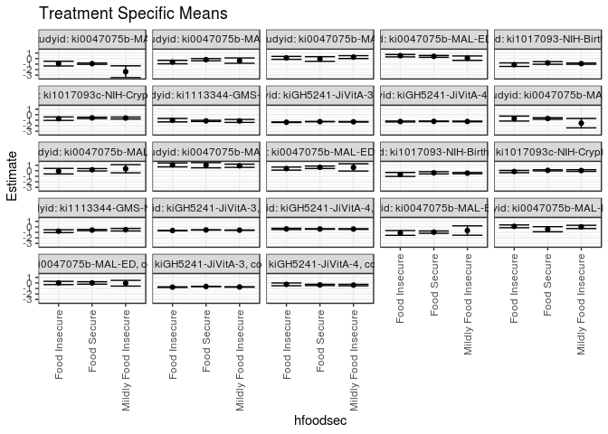

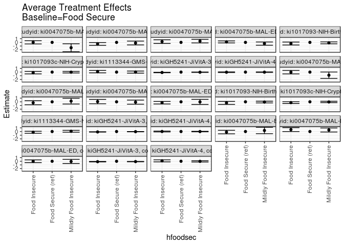

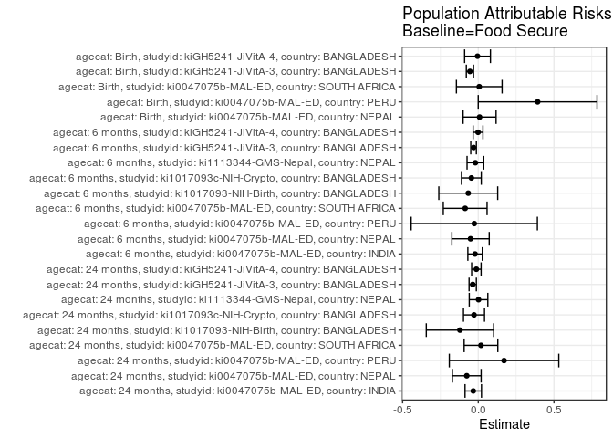

## Results Table

### Parameter: TSM

| agecat | studyid | country | intervention_level | baseline_level | estimate | ci_lower | ci_upper |
| --- | --- | --- | --- | --- | --- | --- | --- |
| Birth | ki0047075b-MAL-ED | NEPAL | Food Secure | NA | -0.9589333 | -1.1679562 | -0.7499105 |
| Birth | ki0047075b-MAL-ED | NEPAL | Mildly Food Insecure | NA | -0.6700000 | -1.5216911 | 0.1816911 |
| Birth | ki0047075b-MAL-ED | NEPAL | Food Insecure | NA | -1.1066667 | -1.5431611 | -0.6701723 |
| Birth | ki0047075b-MAL-ED | PERU | Food Secure | NA | -0.4317144 | -0.8940453 | 0.0306164 |
| Birth | ki0047075b-MAL-ED | PERU | Mildly Food Insecure | NA | -0.0101275 | -0.3051451 | 0.2848901 |
| Birth | ki0047075b-MAL-ED | PERU | Food Insecure | NA | 0.0916349 | -0.1648330 | 0.3481029 |
| Birth | ki0047075b-MAL-ED | SOUTH AFRICA | Food Secure | NA | -0.0027100 | -0.2230672 | 0.2176472 |
| Birth | ki0047075b-MAL-ED | SOUTH AFRICA | Mildly Food Insecure | NA | -0.0569473 | -0.5795027 | 0.4656081 |
| Birth | ki0047075b-MAL-ED | SOUTH AFRICA | Food Insecure | NA | -0.0068436 | -0.3034525 | 0.2897652 |
| Birth | kiGH5241-JiVitA-3 | BANGLADESH | Food Secure | NA | -0.6441151 | -0.6782752 | -0.6099549 |
| Birth | kiGH5241-JiVitA-3 | BANGLADESH | Mildly Food Insecure | NA | -0.7356569 | -0.7764289 | -0.6948848 |
| Birth | kiGH5241-JiVitA-3 | BANGLADESH | Food Insecure | NA | -0.7612834 | -0.8148938 | -0.7076730 |
| Birth | kiGH5241-JiVitA-4 | BANGLADESH | Food Secure | NA | -0.3630428 | -0.4812001 | -0.2448855 |
| Birth | kiGH5241-JiVitA-4 | BANGLADESH | Mildly Food Insecure | NA | -0.3901900 | -0.5222566 | -0.2581234 |
| Birth | kiGH5241-JiVitA-4 | BANGLADESH | Food Insecure | NA | -0.2561227 | -0.5087204 | -0.0035250 |
| 6 months | ki0047075b-MAL-ED | INDIA | Food Secure | NA | -0.6943421 | -0.8349961 | -0.5536881 |
| 6 months | ki0047075b-MAL-ED | INDIA | Mildly Food Insecure | NA | -1.5420000 | -2.3989104 | -0.6850896 |
| 6 months | ki0047075b-MAL-ED | INDIA | Food Insecure | NA | -0.7090196 | -1.1598311 | -0.2582081 |
| 6 months | ki0047075b-MAL-ED | NEPAL | Food Secure | NA | 0.1800148 | -0.0400316 | 0.4000612 |
| 6 months | ki0047075b-MAL-ED | NEPAL | Mildly Food Insecure | NA | 0.3634609 | -0.3806507 | 1.1075725 |
| 6 months | ki0047075b-MAL-ED | NEPAL | Food Insecure | NA | -0.0755474 | -0.5803467 | 0.4292520 |
| 6 months | ki0047075b-MAL-ED | PERU | Food Secure | NA | 1.0056490 | 0.5347627 | 1.4765353 |
| 6 months | ki0047075b-MAL-ED | PERU | Mildly Food Insecure | NA | 0.9099913 | 0.6187122 | 1.2012704 |
| 6 months | ki0047075b-MAL-ED | PERU | Food Insecure | NA | 1.0634303 | 0.7055180 | 1.4213425 |
| 6 months | ki0047075b-MAL-ED | SOUTH AFRICA | Food Secure | NA | 0.6288186 | 0.4110653 | 0.8465718 |
| 6 months | ki0047075b-MAL-ED | SOUTH AFRICA | Mildly Food Insecure | NA | 0.6080683 | -0.0515682 | 1.2677047 |
| 6 months | ki0047075b-MAL-ED | SOUTH AFRICA | Food Insecure | NA | 0.3952422 | 0.1206209 | 0.6698635 |
| 6 months | ki1017093-NIH-Birth | BANGLADESH | Food Secure | NA | -0.3726330 | -0.5763196 | -0.1689465 |
| 6 months | ki1017093-NIH-Birth | BANGLADESH | Mildly Food Insecure | NA | -0.4338160 | -0.5370088 | -0.3306233 |
| 6 months | ki1017093-NIH-Birth | BANGLADESH | Food Insecure | NA | -0.6635482 | -1.0212572 | -0.3058392 |
| 6 months | ki1017093c-NIH-Crypto | BANGLADESH | Food Secure | NA | 0.0753717 | -0.0301853 | 0.1809288 |
| 6 months | ki1017093c-NIH-Crypto | BANGLADESH | Mildly Food Insecure | NA | 0.0379707 | -0.1152239 | 0.1911653 |
| 6 months | ki1017093c-NIH-Crypto | BANGLADESH | Food Insecure | NA | -0.1440226 | -0.3525806 | 0.0645353 |
| 6 months | ki1113344-GMS-Nepal | NEPAL | Food Secure | NA | -0.5838262 | -0.6909040 | -0.4767483 |
| 6 months | ki1113344-GMS-Nepal | NEPAL | Mildly Food Insecure | NA | -0.5150526 | -0.7467500 | -0.2833552 |
| 6 months | ki1113344-GMS-Nepal | NEPAL | Food Insecure | NA | -0.7883022 | -1.0430890 | -0.5335154 |
| 6 months | kiGH5241-JiVitA-3 | BANGLADESH | Food Secure | NA | -0.5619708 | -0.5895240 | -0.5344175 |
| 6 months | kiGH5241-JiVitA-3 | BANGLADESH | Mildly Food Insecure | NA | -0.6001989 | -0.6312139 | -0.5691840 |
| 6 months | kiGH5241-JiVitA-3 | BANGLADESH | Food Insecure | NA | -0.6691219 | -0.7152832 | -0.6229606 |
| 6 months | kiGH5241-JiVitA-4 | BANGLADESH | Food Secure | NA | -0.3879657 | -0.4365264 | -0.3394050 |
| 6 months | kiGH5241-JiVitA-4 | BANGLADESH | Mildly Food Insecure | NA | -0.3964581 | -0.4549438 | -0.3379725 |
| 6 months | kiGH5241-JiVitA-4 | BANGLADESH | Food Insecure | NA | -0.3762040 | -0.4881226 | -0.2642854 |
| 24 months | ki0047075b-MAL-ED | INDIA | Food Secure | NA | -0.9263947 | -1.0447734 | -0.8080160 |
| 24 months | ki0047075b-MAL-ED | INDIA | Mildly Food Insecure | NA | -2.3840000 | -3.4554070 | -1.3125930 |
| 24 months | ki0047075b-MAL-ED | INDIA | Food Insecure | NA | -0.9111765 | -1.3418053 | -0.4805476 |
| 24 months | ki0047075b-MAL-ED | NEPAL | Food Secure | NA | -0.1997124 | -0.4006718 | 0.0012470 |
| 24 months | ki0047075b-MAL-ED | NEPAL | Mildly Food Insecure | NA | -0.3713771 | -0.8531796 | 0.1104254 |
| 24 months | ki0047075b-MAL-ED | NEPAL | Food Insecure | NA | -0.6290947 | -0.9413586 | -0.3168307 |
| 24 months | ki0047075b-MAL-ED | PERU | Food Secure | NA | -0.0722314 | -0.4957112 | 0.3512485 |
| 24 months | ki0047075b-MAL-ED | PERU | Mildly Food Insecure | NA | 0.2692144 | 0.0108887 | 0.5275401 |
| 24 months | ki0047075b-MAL-ED | PERU | Food Insecure | NA | 0.1300456 | -0.1386501 | 0.3987413 |
| 24 months | ki0047075b-MAL-ED | SOUTH AFRICA | Food Secure | NA | 0.4086658 | 0.2414726 | 0.5758591 |
| 24 months | ki0047075b-MAL-ED | SOUTH AFRICA | Mildly Food Insecure | NA | 0.0713570 | -0.3286967 | 0.4714106 |
| 24 months | ki0047075b-MAL-ED | SOUTH AFRICA | Food Insecure | NA | 0.5287343 | 0.3145203 | 0.7429483 |
| 24 months | ki1017093-NIH-Birth | BANGLADESH | Food Secure | NA | -0.7905070 | -1.0305199 | -0.5504941 |
| 24 months | ki1017093-NIH-Birth | BANGLADESH | Mildly Food Insecure | NA | -0.9173960 | -1.0317697 | -0.8030223 |
| 24 months | ki1017093-NIH-Birth | BANGLADESH | Food Insecure | NA | -1.1083554 | -1.4301202 | -0.7865907 |
| 24 months | ki1017093c-NIH-Crypto | BANGLADESH | Food Secure | NA | -0.5820316 | -0.7078172 | -0.4562461 |
| 24 months | ki1017093c-NIH-Crypto | BANGLADESH | Mildly Food Insecure | NA | -0.6056403 | -0.7848491 | -0.4264315 |
| 24 months | ki1017093c-NIH-Crypto | BANGLADESH | Food Insecure | NA | -0.7316909 | -1.0435888 | -0.4197930 |
| 24 months | ki1113344-GMS-Nepal | NEPAL | Food Secure | NA | -1.1274645 | -1.2318006 | -1.0231284 |
| 24 months | ki1113344-GMS-Nepal | NEPAL | Mildly Food Insecure | NA | -1.1345466 | -1.3994094 | -0.8696839 |
| 24 months | ki1113344-GMS-Nepal | NEPAL | Food Insecure | NA | -0.9987555 | -1.3109699 | -0.6865410 |
| 24 months | kiGH5241-JiVitA-3 | BANGLADESH | Food Secure | NA | -1.2620490 | -1.2951899 | -1.2289081 |
| 24 months | kiGH5241-JiVitA-3 | BANGLADESH | Mildly Food Insecure | NA | -1.2968303 | -1.3387550 | -1.2549055 |
| 24 months | kiGH5241-JiVitA-3 | BANGLADESH | Food Insecure | NA | -1.3718003 | -1.4254016 | -1.3181989 |
| 24 months | kiGH5241-JiVitA-4 | BANGLADESH | Food Secure | NA | -1.2116752 | -1.2561949 | -1.1671555 |
| 24 months | kiGH5241-JiVitA-4 | BANGLADESH | Mildly Food Insecure | NA | -1.2336187 | -1.2894162 | -1.1778212 |
| 24 months | kiGH5241-JiVitA-4 | BANGLADESH | Food Insecure | NA | -1.2455860 | -1.3275298 | -1.1636422 |

### Parameter: E(Y)

| agecat | studyid | country | intervention_level | baseline_level | estimate | ci_lower | ci_upper |
| --- | --- | --- | --- | --- | --- | --- | --- |
| Birth | ki0047075b-MAL-ED | NEPAL | NA | NA | -0.9503125 | -1.1412124 | -0.7594126 |
| Birth | ki0047075b-MAL-ED | PERU | NA | NA | -0.0395238 | -0.2249300 | 0.1458824 |
| Birth | ki0047075b-MAL-ED | SOUTH AFRICA | NA | NA | 0.0036788 | -0.1626160 | 0.1699735 |
| Birth | kiGH5241-JiVitA-3 | BANGLADESH | NA | NA | -0.6992565 | -0.7232731 | -0.6752399 |
| Birth | kiGH5241-JiVitA-4 | BANGLADESH | NA | NA | -0.3680294 | -0.4489214 | -0.2871374 |
| 6 months | ki0047075b-MAL-ED | INDIA | NA | NA | -0.7155110 | -0.8495147 | -0.5815073 |
| 6 months | ki0047075b-MAL-ED | NEPAL | NA | NA | 0.1289063 | -0.0638567 | 0.3216692 |
| 6 months | ki0047075b-MAL-ED | PERU | NA | NA | 0.9790991 | 0.7644567 | 1.1937415 |
| 6 months | ki0047075b-MAL-ED | SOUTH AFRICA | NA | NA | 0.5422442 | 0.3806254 | 0.7038629 |
| 6 months | ki1017093-NIH-Birth | BANGLADESH | NA | NA | -0.4389101 | -0.5279432 | -0.3498771 |
| 6 months | ki1017093c-NIH-Crypto | BANGLADESH | NA | NA | 0.0297622 | -0.0491685 | 0.1086930 |
| 6 months | ki1113344-GMS-Nepal | NEPAL | NA | NA | -0.6028654 | -0.6902793 | -0.5154516 |
| 6 months | kiGH5241-JiVitA-3 | BANGLADESH | NA | NA | -0.5932301 | -0.6127836 | -0.5736767 |
| 6 months | kiGH5241-JiVitA-4 | BANGLADESH | NA | NA | -0.3895527 | -0.4270314 | -0.3520739 |
| 24 months | ki0047075b-MAL-ED | INDIA | NA | NA | -0.9595519 | -1.0781202 | -0.8409836 |
| 24 months | ki0047075b-MAL-ED | NEPAL | NA | NA | -0.2757812 | -0.4379560 | -0.1136065 |
| 24 months | ki0047075b-MAL-ED | PERU | NA | NA | 0.0979907 | -0.0798724 | 0.2758537 |
| 24 months | ki0047075b-MAL-ED | SOUTH AFRICA | NA | NA | 0.4264693 | 0.3032402 | 0.5496984 |
| 24 months | ki1017093-NIH-Birth | BANGLADESH | NA | NA | -0.9115790 | -1.0095022 | -0.8136559 |
| 24 months | ki1017093c-NIH-Crypto | BANGLADESH | NA | NA | -0.6103502 | -0.7050157 | -0.5156847 |
| 24 months | ki1113344-GMS-Nepal | NEPAL | NA | NA | -1.1257803 | -1.2146168 | -1.0369438 |
| 24 months | kiGH5241-JiVitA-3 | BANGLADESH | NA | NA | -1.2988352 | -1.3224626 | -1.2752078 |
| 24 months | kiGH5241-JiVitA-4 | BANGLADESH | NA | NA | -1.2243590 | -1.2566569 | -1.1920612 |

### Parameter: ATE

| agecat | studyid | country | intervention_level | baseline_level | estimate | ci_lower | ci_upper |
| --- | --- | --- | --- | --- | --- | --- | --- |
| Birth | ki0047075b-MAL-ED | NEPAL | Food Secure | Food Secure | 0.0000000 | 0.0000000 | 0.0000000 |
| Birth | ki0047075b-MAL-ED | NEPAL | Mildly Food Insecure | Food Secure | 0.2889333 | -0.5880320 | 1.1658987 |
| Birth | ki0047075b-MAL-ED | NEPAL | Food Insecure | Food Secure | -0.1477333 | -0.6316940 | 0.3362273 |
| Birth | ki0047075b-MAL-ED | PERU | Food Secure | Food Secure | 0.0000000 | 0.0000000 | 0.0000000 |
| Birth | ki0047075b-MAL-ED | PERU | Mildly Food Insecure | Food Secure | 0.4215869 | -0.1320955 | 0.9752693 |
| Birth | ki0047075b-MAL-ED | PERU | Food Insecure | Food Secure | 0.5233494 | -0.0083742 | 1.0550730 |
| Birth | ki0047075b-MAL-ED | SOUTH AFRICA | Food Secure | Food Secure | 0.0000000 | 0.0000000 | 0.0000000 |
| Birth | ki0047075b-MAL-ED | SOUTH AFRICA | Mildly Food Insecure | Food Secure | -0.0542373 | -0.6236420 | 0.5151673 |
| Birth | ki0047075b-MAL-ED | SOUTH AFRICA | Food Insecure | Food Secure | -0.0041337 | -0.3726007 | 0.3643334 |
| Birth | kiGH5241-JiVitA-3 | BANGLADESH | Food Secure | Food Secure | 0.0000000 | 0.0000000 | 0.0000000 |
| Birth | kiGH5241-JiVitA-3 | BANGLADESH | Mildly Food Insecure | Food Secure | -0.0915418 | -0.1427296 | -0.0403541 |
| Birth | kiGH5241-JiVitA-3 | BANGLADESH | Food Insecure | Food Secure | -0.1171684 | -0.1788296 | -0.0555072 |
| Birth | kiGH5241-JiVitA-4 | BANGLADESH | Food Secure | Food Secure | 0.0000000 | 0.0000000 | 0.0000000 |
| Birth | kiGH5241-JiVitA-4 | BANGLADESH | Mildly Food Insecure | Food Secure | -0.0271472 | -0.2064461 | 0.1521518 |
| Birth | kiGH5241-JiVitA-4 | BANGLADESH | Food Insecure | Food Secure | 0.1069201 | -0.1722051 | 0.3860453 |
| 6 months | ki0047075b-MAL-ED | INDIA | Food Secure | Food Secure | 0.0000000 | 0.0000000 | 0.0000000 |
| 6 months | ki0047075b-MAL-ED | INDIA | Mildly Food Insecure | Food Secure | -0.8476579 | -1.7160351 | 0.0207193 |
| 6 months | ki0047075b-MAL-ED | INDIA | Food Insecure | Food Secure | -0.0146775 | -0.4869217 | 0.4575667 |
| 6 months | ki0047075b-MAL-ED | NEPAL | Food Secure | Food Secure | 0.0000000 | 0.0000000 | 0.0000000 |
| 6 months | ki0047075b-MAL-ED | NEPAL | Mildly Food Insecure | Food Secure | 0.1834461 | -0.5923465 | 0.9592386 |
| 6 months | ki0047075b-MAL-ED | NEPAL | Food Insecure | Food Secure | -0.2555622 | -0.8095646 | 0.2984402 |
| 6 months | ki0047075b-MAL-ED | PERU | Food Secure | Food Secure | 0.0000000 | 0.0000000 | 0.0000000 |
| 6 months | ki0047075b-MAL-ED | PERU | Mildly Food Insecure | Food Secure | -0.0956577 | -0.6567153 | 0.4654000 |
| 6 months | ki0047075b-MAL-ED | PERU | Food Insecure | Food Secure | 0.0577813 | -0.5404054 | 0.6559679 |
| 6 months | ki0047075b-MAL-ED | SOUTH AFRICA | Food Secure | Food Secure | 0.0000000 | 0.0000000 | 0.0000000 |
| 6 months | ki0047075b-MAL-ED | SOUTH AFRICA | Mildly Food Insecure | Food Secure | -0.0207503 | -0.7151486 | 0.6736480 |
| 6 months | ki0047075b-MAL-ED | SOUTH AFRICA | Food Insecure | Food Secure | -0.2335764 | -0.5852534 | 0.1181007 |
| 6 months | ki1017093-NIH-Birth | BANGLADESH | Food Secure | Food Secure | 0.0000000 | 0.0000000 | 0.0000000 |
| 6 months | ki1017093-NIH-Birth | BANGLADESH | Mildly Food Insecure | Food Secure | -0.0611830 | -0.2898899 | 0.1675239 |
| 6 months | ki1017093-NIH-Birth | BANGLADESH | Food Insecure | Food Secure | -0.2909151 | -0.7037905 | 0.1219602 |
| 6 months | ki1017093c-NIH-Crypto | BANGLADESH | Food Secure | Food Secure | 0.0000000 | 0.0000000 | 0.0000000 |
| 6 months | ki1017093c-NIH-Crypto | BANGLADESH | Mildly Food Insecure | Food Secure | -0.0374010 | -0.2236128 | 0.1488107 |
| 6 months | ki1017093c-NIH-Crypto | BANGLADESH | Food Insecure | Food Secure | -0.2193944 | -0.4532774 | 0.0144886 |
| 6 months | ki1113344-GMS-Nepal | NEPAL | Food Secure | Food Secure | 0.0000000 | 0.0000000 | 0.0000000 |
| 6 months | ki1113344-GMS-Nepal | NEPAL | Mildly Food Insecure | Food Secure | 0.0687736 | -0.1863115 | 0.3238586 |
| 6 months | ki1113344-GMS-Nepal | NEPAL | Food Insecure | Food Secure | -0.2044760 | -0.4815523 | 0.0726003 |
| 6 months | kiGH5241-JiVitA-3 | BANGLADESH | Food Secure | Food Secure | 0.0000000 | 0.0000000 | 0.0000000 |
| 6 months | kiGH5241-JiVitA-3 | BANGLADESH | Mildly Food Insecure | Food Secure | -0.0382282 | -0.0789201 | 0.0024638 |
| 6 months | kiGH5241-JiVitA-3 | BANGLADESH | Food Insecure | Food Secure | -0.1071511 | -0.1587879 | -0.0555144 |
| 6 months | kiGH5241-JiVitA-4 | BANGLADESH | Food Secure | Food Secure | 0.0000000 | 0.0000000 | 0.0000000 |
| 6 months | kiGH5241-JiVitA-4 | BANGLADESH | Mildly Food Insecure | Food Secure | -0.0084925 | -0.0804781 | 0.0634932 |
| 6 months | kiGH5241-JiVitA-4 | BANGLADESH | Food Insecure | Food Secure | 0.0117617 | -0.1071258 | 0.1306492 |
| 24 months | ki0047075b-MAL-ED | INDIA | Food Secure | Food Secure | 0.0000000 | 0.0000000 | 0.0000000 |
| 24 months | ki0047075b-MAL-ED | INDIA | Mildly Food Insecure | Food Secure | -1.4576053 | -2.5355322 | -0.3796783 |
| 24 months | ki0047075b-MAL-ED | INDIA | Food Insecure | Food Secure | 0.0152183 | -0.4313853 | 0.4618218 |
| 24 months | ki0047075b-MAL-ED | NEPAL | Food Secure | Food Secure | 0.0000000 | 0.0000000 | 0.0000000 |
| 24 months | ki0047075b-MAL-ED | NEPAL | Mildly Food Insecure | Food Secure | -0.1716647 | -0.6934526 | 0.3501232 |
| 24 months | ki0047075b-MAL-ED | NEPAL | Food Insecure | Food Secure | -0.4293823 | -0.7991295 | -0.0596350 |
| 24 months | ki0047075b-MAL-ED | PERU | Food Secure | Food Secure | 0.0000000 | 0.0000000 | 0.0000000 |
| 24 months | ki0047075b-MAL-ED | PERU | Mildly Food Insecure | Food Secure | 0.3414458 | -0.1487447 | 0.8316363 |
| 24 months | ki0047075b-MAL-ED | PERU | Food Insecure | Food Secure | 0.2022770 | -0.3051129 | 0.7096669 |
| 24 months | ki0047075b-MAL-ED | SOUTH AFRICA | Food Secure | Food Secure | 0.0000000 | 0.0000000 | 0.0000000 |
| 24 months | ki0047075b-MAL-ED | SOUTH AFRICA | Mildly Food Insecure | Food Secure | -0.3373089 | -0.7715845 | 0.0969667 |
| 24 months | ki0047075b-MAL-ED | SOUTH AFRICA | Food Insecure | Food Secure | 0.1200685 | -0.1525852 | 0.3927222 |
| 24 months | ki1017093-NIH-Birth | BANGLADESH | Food Secure | Food Secure | 0.0000000 | 0.0000000 | 0.0000000 |
| 24 months | ki1017093-NIH-Birth | BANGLADESH | Mildly Food Insecure | Food Secure | -0.1268891 | -0.3926582 | 0.1388801 |
| 24 months | ki1017093-NIH-Birth | BANGLADESH | Food Insecure | Food Secure | -0.3178485 | -0.7193443 | 0.0836474 |
| 24 months | ki1017093c-NIH-Crypto | BANGLADESH | Food Secure | Food Secure | 0.0000000 | 0.0000000 | 0.0000000 |
| 24 months | ki1017093c-NIH-Crypto | BANGLADESH | Mildly Food Insecure | Food Secure | -0.0236087 | -0.2410910 | 0.1938737 |
| 24 months | ki1017093c-NIH-Crypto | BANGLADESH | Food Insecure | Food Secure | -0.1496593 | -0.4851971 | 0.1858785 |
| 24 months | ki1113344-GMS-Nepal | NEPAL | Food Secure | Food Secure | 0.0000000 | 0.0000000 | 0.0000000 |
| 24 months | ki1113344-GMS-Nepal | NEPAL | Mildly Food Insecure | Food Secure | -0.0070822 | -0.2929779 | 0.2788136 |
| 24 months | ki1113344-GMS-Nepal | NEPAL | Food Insecure | Food Secure | 0.1287090 | -0.2035852 | 0.4610032 |
| 24 months | kiGH5241-JiVitA-3 | BANGLADESH | Food Secure | Food Secure | 0.0000000 | 0.0000000 | 0.0000000 |
| 24 months | kiGH5241-JiVitA-3 | BANGLADESH | Mildly Food Insecure | Food Secure | -0.0347813 | -0.0872114 | 0.0176489 |
| 24 months | kiGH5241-JiVitA-3 | BANGLADESH | Food Insecure | Food Secure | -0.1097513 | -0.1709304 | -0.0485721 |
| 24 months | kiGH5241-JiVitA-4 | BANGLADESH | Food Secure | Food Secure | 0.0000000 | 0.0000000 | 0.0000000 |
| 24 months | kiGH5241-JiVitA-4 | BANGLADESH | Mildly Food Insecure | Food Secure | -0.0219435 | -0.0926156 | 0.0487286 |
| 24 months | kiGH5241-JiVitA-4 | BANGLADESH | Food Insecure | Food Secure | -0.0339108 | -0.1273382 | 0.0595166 |

### Parameter: PAR

| agecat | studyid | country | intervention_level | baseline_level | estimate | ci_lower | ci_upper |
| --- | --- | --- | --- | --- | --- | --- | --- |
| Birth | ki0047075b-MAL-ED | NEPAL | Food Secure | NA | 0.0086208 | -0.1003141 | 0.1175558 |
| Birth | ki0047075b-MAL-ED | PERU | Food Secure | NA | 0.3921906 | -0.0002850 | 0.7846662 |
| Birth | ki0047075b-MAL-ED | SOUTH AFRICA | Food Secure | NA | 0.0063887 | -0.1445333 | 0.1573108 |
| Birth | kiGH5241-JiVitA-3 | BANGLADESH | Food Secure | NA | -0.0551414 | -0.0789658 | -0.0313170 |
| Birth | kiGH5241-JiVitA-4 | BANGLADESH | Food Secure | NA | -0.0049866 | -0.0902940 | 0.0803208 |
| 6 months | ki0047075b-MAL-ED | INDIA | Food Secure | NA | -0.0211689 | -0.0689128 | 0.0265750 |
| 6 months | ki0047075b-MAL-ED | NEPAL | Food Secure | NA | -0.0511086 | -0.1744845 | 0.0722674 |
| 6 months | ki0047075b-MAL-ED | PERU | Food Secure | NA | -0.0265499 | -0.4435222 | 0.3904224 |
| 6 months | ki0047075b-MAL-ED | SOUTH AFRICA | Food Secure | NA | -0.0865744 | -0.2312627 | 0.0581139 |
| 6 months | ki1017093-NIH-Birth | BANGLADESH | Food Secure | NA | -0.0662771 | -0.2607837 | 0.1282295 |
| 6 months | ki1017093c-NIH-Crypto | BANGLADESH | Food Secure | NA | -0.0456095 | -0.1110145 | 0.0197956 |
| 6 months | ki1113344-GMS-Nepal | NEPAL | Food Secure | NA | -0.0190393 | -0.0741198 | 0.0360412 |
| 6 months | kiGH5241-JiVitA-3 | BANGLADESH | Food Secure | NA | -0.0312594 | -0.0498146 | -0.0127042 |
| 6 months | kiGH5241-JiVitA-4 | BANGLADESH | Food Secure | NA | -0.0015870 | -0.0340033 | 0.0308293 |
| 24 months | ki0047075b-MAL-ED | INDIA | Food Secure | NA | -0.0331571 | -0.0875022 | 0.0211879 |
| 24 months | ki0047075b-MAL-ED | NEPAL | Food Secure | NA | -0.0760688 | -0.1709543 | 0.0188166 |
| 24 months | ki0047075b-MAL-ED | PERU | Food Secure | NA | 0.1702220 | -0.1914838 | 0.5319278 |
| 24 months | ki0047075b-MAL-ED | SOUTH AFRICA | Food Secure | NA | 0.0178035 | -0.0934388 | 0.1290458 |
| 24 months | ki1017093-NIH-Birth | BANGLADESH | Food Secure | NA | -0.1210721 | -0.3435120 | 0.1013678 |
| 24 months | ki1017093c-NIH-Crypto | BANGLADESH | Food Secure | NA | -0.0283186 | -0.0977801 | 0.0411430 |
| 24 months | ki1113344-GMS-Nepal | NEPAL | Food Secure | NA | 0.0016842 | -0.0596895 | 0.0630579 |
| 24 months | kiGH5241-JiVitA-3 | BANGLADESH | Food Secure | NA | -0.0367862 | -0.0608237 | -0.0127486 |
| 24 months | kiGH5241-JiVitA-4 | BANGLADESH | Food Secure | NA | -0.0126838 | -0.0439198 | 0.0185522 |